# DS202W - Spring Term Summative

##### Plot: Heat Map - raw counts

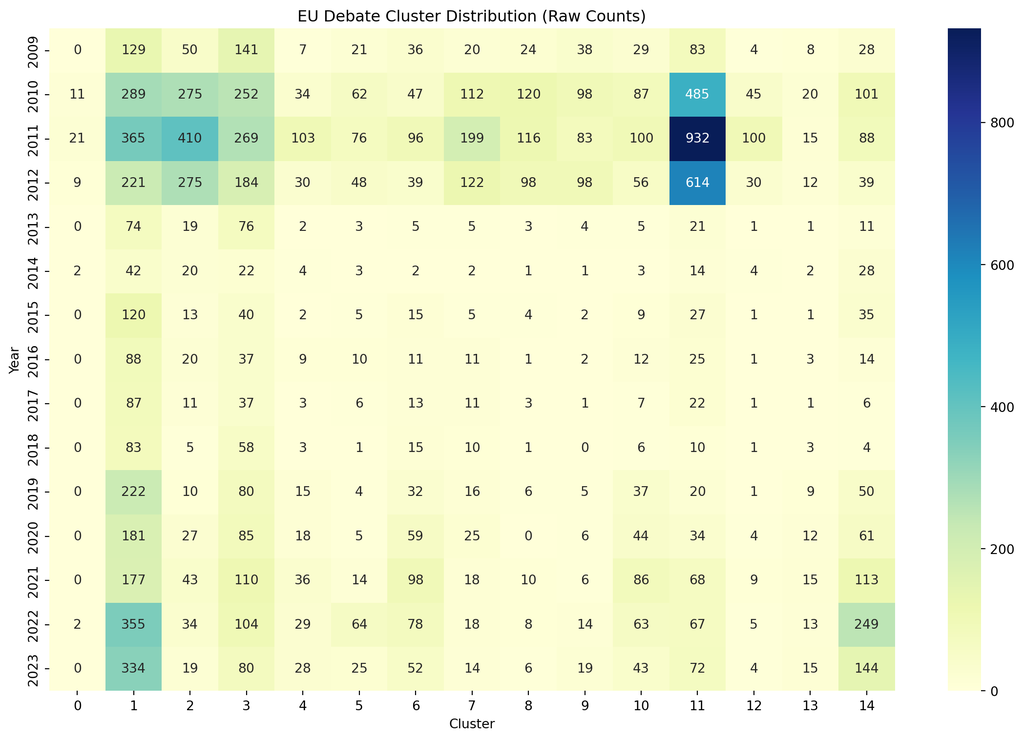

```python
plt.figure(figsize=(12,8))
sns.heatmap(cluster_time_pivot, annot=True, fmt=".0f", cmap="YlGnBu")
plt.xlabel("Cluster")
plt.ylabel("Year")
plt.title("EU Debate Cluster Distribution (Raw Counts)")
plt.tight_layout()
plt.show()
```

##### Now, we already have 2 diagrams. However, although our diagrams display cluster numbers, without knowing the underlying topics of those clusters, it is almost impossible to draw meaningful conclusions. Therefore, profiling each cluster by identifying its keywords is essential. In this part, I will extract the top words for each cluster to interpret the dominant themes, and to better understand what each group represents.

```python
feature_names = tfidf_vectorizer.get_feature_names_out()
num_top_words = 15
cluster_profiles = {}


for cluster_label in sorted(eu_df_sample['cluster'].unique()):
    cluster_indices = eu_df_sample.index[eu_df_sample['cluster'] == cluster_label].tolist()

    mean_vector = tfidf_matrix[cluster_indices].mean(axis=0)
    mean_vector = np.asarray(mean_vector).flatten()

    top_indices = mean_vector.argsort()[::-1][:num_top_words]
    top_words = [feature_names[i] for i in top_indices]

    cluster_profiles[cluster_label] = top_words


for cluster_label, top_words in cluster_profiles.items():
    print(f"Cluster {cluster_label}: Top words: {', '.join(top_words)}")
```

```
Cluster 0: Top words: switzerland, swiss, liechtenstein, confederation, agreement, principality, norway, iceland, agricultural, products, european, schengen, eu, indications, designations
Cluster 1: Top words: mr, president, people, like, vote, think, european, thank, parliament, debate, question, europe, just, commission, want
Cluster 2: Top words: social, economic, crisis, european, financial, growth, employment, workers, states, member, fund, eu, market, people, europe
Cluster 3: Top words: european, council, parliament, commission, union, budget, europe, mr, need, like, member, work, states, citizens, president
Cluster 4: Top words: women, violence, gender, equality, men, womens, rights, girls, sexual, work, equal, european, female, report, genderbased
Cluster 5: Top words: energy, gas, nuclear, renewable, supply, efficiency, european, need, security, eu, projects, sources, europe, market, member
Cluster 6: Top words: law, european, rule, member, states, asylum, schengen, eu, migration, commission, union, justice, borders, need, rights
Cluster 7: Top words: trade, agreement, eu, agreements, countries, european, international, union, china, products, wto, development, negotiations, new, economic
Cluster 8: Top words: fishing, fisheries, policy, cohesion, sea, fish, regions, maritime, development, european, regional, report, eu, stocks, strategy
Cluster 9: Top words: food, farmers, agricultural, milk, dairy, agriculture, products, cap, production, european, prices, producers, policy, sector, consumers
Cluster 10: Top words: rights, human, eu, european, fundamental, people, freedom, right, respect, union, president, law, democracy, political, international
Cluster 11: Top words: report, european, voted, member, eu, favour, states, directive, regulation, market, proposal, financial, commission, information, parliament
Cluster 12: Top words: transport, passengers, rail, railway, road, air, european, safety, rights, sector, bus, regulation, freight, airlines, coach
Cluster 13: Top words: closed, written, statements, debate, rule, vote, place, wednesday, shortly, motions, today, suspended, thursday, tomorrow, received
Cluster 14: Top words: ukraine, russia, eu, war, european, russian, security, president, union, people, support, country, moldova, political, international
```

#### Part 2-4: Method 2 - LDA

##### Section 3: I extract the topic profiles by retrieving the feature names from the CountVectorizer and, for each of the 15 topics, identify the top 15 words (same as K-means approach) by sorting the topic-component weights in descending order, thereby providing a clear linguistic description of each topic.

##### Section 4: I apply the LDA model to transform the document-term matrix, obtaining a probability distribution over topics for each document, and then assign each document its dominant topic by selecting the topic with the highest probability, facilitating subsequent analysis and visualization of topic trends over time.

```python
# Section 1
count_vectorizer = CountVectorizer(stop_words='english', max_df=0.9, min_df=5)
doc_term_matrix = count_vectorizer.fit_transform(eu_df_sample['text'])

# Section 2
n_topics = 15
lda_model = LatentDirichletAllocation(n_components=n_topics, random_state=12345)
lda_model.fit(doc_term_matrix)

# Section 3
feature_names_count = count_vectorizer.get_feature_names_out()
n_top_words = 15
topic_profiles = {}
print("LDA Topic Profiles:")
for topic_idx, topic in enumerate(lda_model.components_):
    top_indices = topic.argsort()[::-1][:n_top_words]
    top_words = [feature_names_count[i] for i in top_indices]
    topic_profiles[topic_idx] = top_words
    print(f"Topic {topic_idx}: {', '.join(top_words)}")

# Section 4
lda_topic_assignments = lda_model.transform(doc_term_matrix)
eu_df_sample['lda_topic'] = lda_topic_assignments.argmax(axis=1)
```

```
LDA Topic Profiles:
Topic 0: women, people, children, need, president, gender, violence, rights, equality, work, madam, europe, support, eu, member
Topic 1: food, farmers, need, president, waste, mr, like, agricultural, sector, production, agriculture, commissioner, prices, european, problem
Topic 2: european, commission, parliament, citizens, union, report, la, ombudsman, eu, institutions, et, treaty, important, le, member
Topic 3: rights, human, law, eu, commission, president, fundamental, international, european, parliament, council, justice, rule, political, situation
Topic 4: eu, member, states, european, eur, solidarity, million, support, aid, crisis, humanitarian, countries, union, people, fund
Topic 5: eu, security, president, need, china, european, russia, ukraine, defence, foreign, support, madam, let, cooperation, world
Topic 6: social, european, market, economic, people, eu, europe, policy, report, employment, transport, development, growth, member, states
Topic 7: climate, commission, need, council, debate, president, parliament, work, change, thank, european, eu, today, green, action
Topic 8: european, union, europe, mr, president, need, states, member, economic, crisis, council, euro, like, countries, presidency
Topic 9: european, financial, budget, commission, parliament, council, report, economic, member, eu, crisis, states, proposal, union, fund
Topic 10: eu, trade, countries, agreement, development, european, policy, international, union, report, economic, cooperation, region, fisheries, fishing
Topic 11: european, people, president, country, democracy, europe, union, ukraine, freedom, law, political, war, government, russia, rule
Topic 12: energy, commission, need, market, president, member, tax, european, mr, think, like, digital, make, states, important
Topic 13: mr, president, people, like, uk, parliament, european, eu, want, say, think, ireland, group, question, just
Topic 14: member, states, european, eu, report, directive, commission, protection, information, voted, regulation, proposal, favour, union, legislation
```

##### Line diagram & Heat map

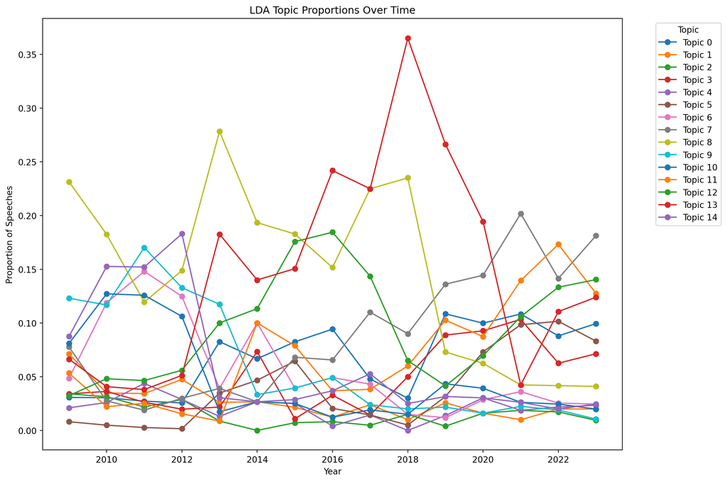

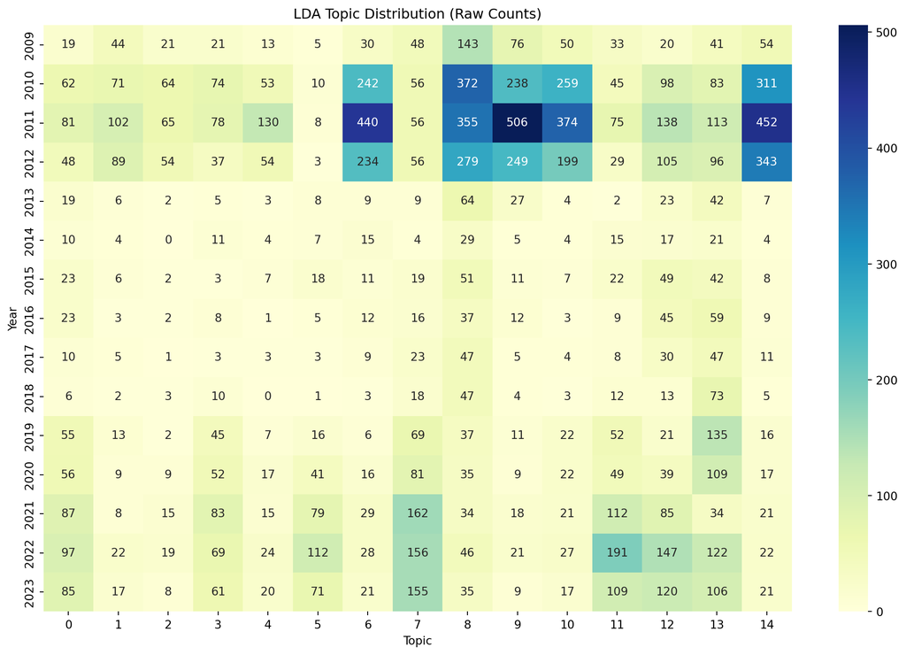

```python
topic_time = eu_df_sample.groupby(['year', 'lda_topic']).size().reset_index(name='count')
topic_time_pivot = topic_time.pivot(index='year', columns='lda_topic', values='count').fillna(0)
topic_time_pivot_percent = topic_time_pivot.apply(lambda x: x / x.sum(), axis=1)

# Line diagram
plt.figure(figsize=(12, 8))
for topic in topic_time_pivot_percent.columns:
    plt.plot(topic_time_pivot_percent.index, topic_time_pivot_percent[topic],
             marker='o', label=f'Topic {topic}')
plt.xlabel("Year")
plt.ylabel("Proportion of Speeches")
plt.title("LDA Topic Proportions Over Time")
plt.legend(title="Topic", bbox_to_anchor=(1.05, 1), loc='upper left')
plt.tight_layout()
plt.show()

# Heat map
plt.figure(figsize=(12, 8))
sns.heatmap(topic_time_pivot, annot=True, fmt=".0f", cmap="YlGnBu")
plt.xlabel("Topic")
plt.ylabel("Year")
plt.title("LDA Topic Distribution (Raw Counts)")
plt.tight_layout()
plt.show()
```

#### Part 2-5 - Unsupervised Learning - Overall Comment:

##### In my analysis, I implement two complementary unsupervised approaches—**K‑Means clustering and LDA topic modeling**—to uncover latent themes in EU English debate speeches. Both methods, despite based on distinct modeling assumptions, converge in revealing notable temporal trends in the data, which enhances the robustness of our findings.

#### Conclusion:

##### In summary, the combined results indicate a clear evolution in EU debate topics: EU debates **in English** during **early stages** (2010–2012) were predominantly centered on **addressing financial and economic challenges**, while more **recent debates** (2019-2023) have **shifted focus towards human rights and geopolitical conflicts**. This technical amalgamation of clustering and topic modeling metrics thus substantiates the inference that external events—both economic and political—have reshaped the EU debate narrative over time.

#### Appendix: AI usage summary:

##### Grammarly: I used Grammarly via the VSCode extension throughout the coding to ensure no obvious grammar errors occur. Occasionally, I also pasted parts of my narrative into Grammarly’s web interface to further refine complex sections and ensure clarity in my observations and conclusions.

##### DeepL: I used DeepL for 2 overall comment sessions in Part 1 and Part 2, for a more concise and precise language.

##### ChatGPT:

##### Part 1:

##### 1, I consulted ChatGPT to validate my approach for sampling the Consumer Complaints dataset, particularly in the pros and cons for different sampling methods; 2, ChatGPT provided insights on how to handle duplicate entries for consumer complaint narratives.

##### Part 2:

##### 1, Initially, I used bar chart (both raw counts & proportions) to visualize outputs of K-means and LDA approaches, but they are not visual friendly due to too many clusters. Chatgpt suggested using Heatmap instead; 2, ChatGPT helped me in filtering out EU speeches that are not in English.

##### General:

##### 1, ChatGPT suggested plotting cumulative explained variance to find n in dimensionality reduction work; 2, ChatGPT helped determine an appropriate sampling percentage for the population.